# 第二章作业

向量的 $L_0$ 范数为向量中非零元素的个数，严格满足向量范数的 3 个性质，是否正确？A. 错误 B. 正确

A. 错误。$L_0$ 范数定义为向量中非零元素的个数，但它不满足向量范数的三角不等式，因此不是严格意义上的范数。

下列说法错误的推导： A. 两个向量相加的矩阵之间相乘一定可交换。B. 矩阵与向量的乘法满足分配律，即 $ A(x + y) = Ax + Ay $. C. 矩阵对向量的乘法满足结合律，即 $ A(Bx) = (AB)x $. D. 假设 假设$f$处处可微且存在最大值，那么在最大值点的梯度一定为零。

错误项为 A 和 D。

- 选项 A：矩阵乘法不一定可交换，错误。
- 选项 B：$ A(x + y) = Ax + Ay $ 成立，正确。
- 选项 C：$ A(Bx) = (AB)x $ 成立，正确。
- 选项 D：显然错误。

当 $ L_p $ 范数中的 $ p \in (0, 1] $ 时，特别是在 $ p \to 0^+ $ 时，得到 $ L_0 $ 范数。问题是 $ L_0 $ 范数是否满足范数的定义，以及如果不满足，违反了哪条要求。

- 范数要求：非负性 $ \| x \| \geq 0 $，齐次性 $ \| \alpha x \| = |\alpha| \| x \| $，三角不等式 $ \| x + y \| \leq \| x \| + \| y \| $。
- $ L_0 $ 范数为非零元素个数，满足非负性。
- 齐次性：取 $ x = (1, 0, 0) $，$ \| x \|_0 = 1 $，$ \alpha = 2 $，$ \alpha x = (2, 0, 0) $，$ \| \alpha x \|_0 = 1 $，但 $ |\alpha| \| x \|_0 = 2 \times 1 = 2 \neq 1 $。不满足

验证矩阵的转置和逆满足 $(A^T)^{-1} = (A^{-1})^T$。

设 $A$ 可逆，则 $AA^{-1} = I$  
取转置得 $(AA^{-1})^T = I^T \implies (A^{-1})^T A^T = I$  
故 $(A^{-1})^T$ 是 $A^T$ 的逆，即 $(A^T)^{-1} = (A^{-1})^T$

设二元函数 $f(x, y)$ 在 $\mathbb{R}^2$ 上处处光滑且可微，证明在任意一点 $(x_0, y_0)$ 处，函数的梯度是函数值上升最快的方向。（提示：考虑函数在该点沿 $(\cos \theta, \sin \theta)$ 方向导数的长度，同时该长度最大？）

设函数 $f(x, y)$ 在 $(x_0, y_0)$ 处可微，其梯度为 $\nabla f = (\frac{\partial f}{\partial x}, \frac{\partial f}{\partial y})$。

沿方向 $(\cos \theta, \sin \theta)$ 的导数为 $\nabla f \cdot (\cos \theta, \sin \theta) = \frac{\partial f}{\partial x} \cos \theta + \frac{\partial f}{\partial y} \sin \theta$。

根据 Cauchy-Schwarz 不等式，$|\nabla f \cdot (\cos \theta, \sin \theta)| \leq \|\nabla f\| \cdot 1$，等号成立当 $(\cos \theta, \sin \theta)$ 与 $\nabla f$ 同向时。因此，梯度方向是函数值上升最快的方向。

利用向量范数的定义证明，所有的向量范数都是凸函数。

向量范数 $\|x\|_p$ 定义为 $(|x_1|^p + |x_2|^p + \cdots + |x_n|^p)^{1/p}$（$p \geq 1$）。

考虑函数 $f(\lambda x + (1-\lambda)y)$，根据 Minkowski 不等式，$\| \lambda x + (1-\lambda)y \|_p \leq \lambda \|x\|_p + (1-\lambda) \|y\|_p$，这表明向量范数是凸函数。

是否存在非凸非凹的函数？又凸又凹呢？试举例说明或证明其不存在。

显然$f(x)=x^3$在整体上非凸非凹，一次函数又凸又凹

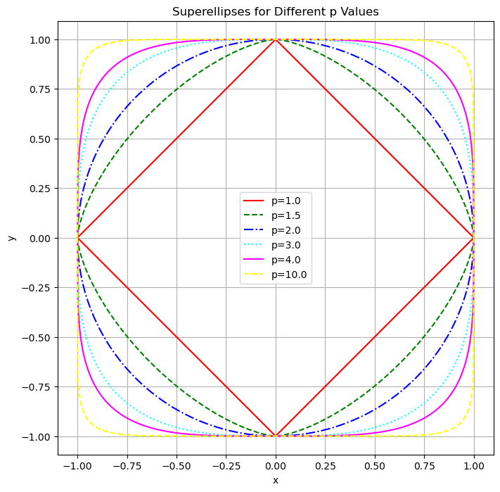

```python
import numpy as np
import matplotlib.pyplot as plt

# Define the values of p to plot
p_values = [1.0, 1.5, 2.0, 3.0, 4.0, 10.0]

# Define colors and linestyles for clarity
colors = ['red', 'green', 'blue', 'cyan', 'magenta', 'yellow']
linestyles = ['-', '--', '-.', ':', '-', '--']

# Create a figure with equal aspect ratio
plt.figure(figsize=(8, 8))

# Loop through each p and plot the corresponding curve
for i, p in enumerate(p_values):
    x = np.linspace(-1, 1, 1000)  # Generate x values from -1 to 1
    y_upper = (1 - np.abs(x)**p)**(1/p)  # Compute upper half of the curve
    y_lower = -y_upper  # Compute lower half of the curve
    plt.plot(x, y_upper, color=colors[i % len(colors)], linestyle=linestyles[i % len(linestyles)], label=f'p={p}')
    plt.plot(x, y_lower, color=colors[i % len(colors)], linestyle=linestyles[i % len(linestyles)])

# Add legend, labels, and title
plt.legend()
plt.xlabel('x')
plt.ylabel('y')
plt.title('Superellipses for Different p Values')
plt.axis('equal')  # Ensure aspect ratio is equal
plt.grid(True)  # Add grid for better visualization
plt.show()
```

# 第三章作业

在 kNN 算法中，我们将训练集上的平方误差和作为选择 $k$ 的标准，是否正确？A. 错误 B. 正确

A. 错误。在 kNN 算法中，$k$ 的选择通常基于交叉验证或错误率，而不是直接使用训练集上的平方误差和。

关于 kNN 算法用于分类和回归问题，哪项是正确的？A. kNN 算法用于分类和回归问题。B. kNN 算法在空间中找到 $k$ 个最近的样本进行预测。C. kNN 算法的 $k$ 是经过学习得到的。

AB

C 错误，因为 $k$ 通常是超参数，而不是通过学习得到的。

本节的 kNN 算法中，我们采用了最常用的欧氏距离作为寻找邻居的标准。在哪些场景下，我们可能会用到其他距离度量，例如曼哈顿距离 (Manhattan distance)？把第 3 节实验中的距离改为曼哈顿距离，观察对分类结果的影响。

```
数据集大小： 200
```

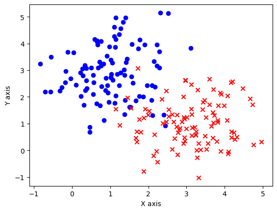

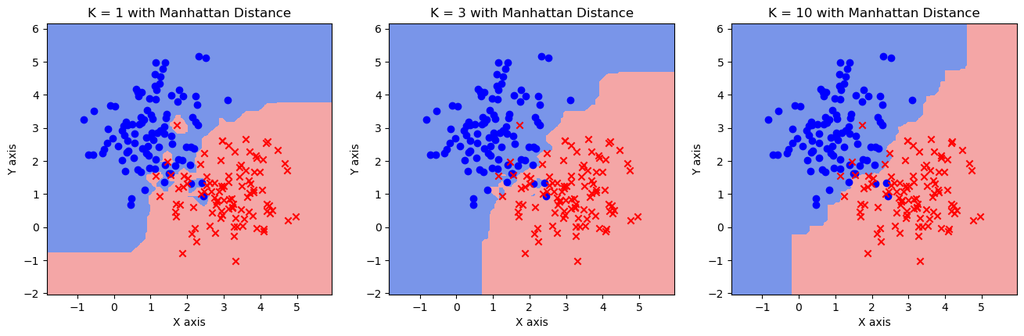

```python
from sklearn.neighbors import KNeighborsClassifier  # sklearn中的KNN分类器
from matplotlib.colors import ListedColormap
import numpy as np
import matplotlib.pyplot as plt

# 读入高斯数据集
data = np.loadtxt('gauss.csv', delimiter=',')
x_train = data[:, :2]
y_train = data[:, 2]
print('数据集大小：', len(x_train))

# 可视化原始数据
plt.figure()
plt.scatter(x_train[y_train == 0, 0], x_train[y_train == 0, 1], c='blue', marker='o')
plt.scatter(x_train[y_train == 1, 0], x_train[y_train == 1, 1], c='red', marker='x')
plt.xlabel('X axis')
plt.ylabel('Y axis')
plt.show()

# 设置步长
step = 0.02
# 设置网格边界
x_min, x_max = np.min(x_train[:, 0]) - 1, np.max(x_train[:, 0]) + 1
y_min, y_max = np.min(x_train[:, 1]) - 1, np.max(x_train[:, 1]) + 1
# 构造网格
xx, yy = np.meshgrid(np.arange(x_min, x_max, step), np.arange(y_min, y_max, step))
grid_data = np.concatenate([xx.reshape(-1, 1), yy.reshape(-1, 1)], axis=1)

fig = plt.figure(figsize=(16, 4.5))
# K值，读者可以自行调整，观察分类结果的变化
ks = [1, 3, 10]
cmap_light = ListedColormap(['royalblue', 'lightcoral'])

for i, k in enumerate(ks):
    # 定义KNN分类器，使用曼哈顿距离
    knn = KNeighborsClassifier(n_neighbors=k, metric='manhattan')
    knn.fit(x_train, y_train)
    z = knn.predict(grid_data)

    # 画出分类结果
    ax = fig.add_subplot(1, 3, i + 1)
    ax.pcolormesh(xx, yy, z.reshape(xx.shape), cmap=cmap_light, alpha=0.7)
    ax.scatter(x_train[y_train == 0, 0], x_train[y_train == 0, 1], c='blue', marker='o')
    ax.scatter(x_train[y_train == 1, 0], x_train[y_train == 1, 1], c='red', marker='x')

    ax.set_xlabel('X axis')
    ax.set_ylabel('Y axis')
    ax.set_title(f'K = {k} with Manhattan Distance')

plt.show()
```

没啥大影响

在色彩风格迁移中，如果扩大采样的窗口，可能会产生什么问题？调整窗口大小并观察结果。

```
 扩大采样的窗口可能导致过度平滑或引入无关信息，降低迁移效果。调整窗口大小后，较小窗口可能保留更多细节，较大窗口可能增强鲁棒性，但需平衡计算成本和效果。
```

思考一下自己在生活、工作中，是否也使过 KNN 算法？自己为什么使用 KNN 算法来处理碰到的问题？

在生活中，例如推荐系统（基于相似用户喜好）或图像识别中，可能使用 kNN 算法。我使用 kNN 是因为它简单直观，适合小规模数据集，且对数据分布假设较少。

# 第四章作业

以下关于线性回归的表述错误的是：A. 线性回归中的"线性"，是指模型参数$\theta$之间不存在非线性耦合项。B. 线性回归常用均方误差作为损失函数。C. $f(x) = \theta_0 + \theta_1/x$可以是一个线性回归得到的模型表达式。D. 损失函数用于量预测值和真实值之间的误差。

C 与标准形式不符合

以下关于梯度下降的表述错误的是： A. 使用梯度信息来最小化目标函数时，参数的更新方向是其梯度的负方向。 B. 梯度下降中设置更大的学习率就可以更快地收敛到全局最优。 C. 随机梯度下降是一种权衡训练速度和稳定性的方法。 D. 损失函数的优化目标是最小化模型在训练集上的误差。

B错 学习率太大有时候会反复横跳

假设在线性回归问题中，数据集有两个样本$\{x_1 = (1,1,1), y_1 = 0\}$和$\{x_2 = (0,1,2), y_2 = 1\}$，尝试用解析方式计算线性回归的参数，计算中是否遇到了问题？

在线性回归问题中，我们需要找到参数向量$\theta$使得损失函数最小化。对于给定的数据：

- $x_1 = (1,1,1)$, $y_1 = 0$
- $x_2 = (0,1,2)$, $y_2 = 1$

使用最小二乘法的解析解：$\theta = (X^TX)^{-1}X^TY$

构建矩阵$X$和向量$Y$： $X = \begin{bmatrix} 1 & 1 & 1 \\ 0 & 1 & 2 \end{bmatrix}$ $Y = \begin{bmatrix} 0 \\ 1 \end{bmatrix}$

计算$X^TX$： $X^TX = \begin{bmatrix} 1 & 0 \\ 1 & 1 \\ 1 & 2 \end{bmatrix} \begin{bmatrix} 1 & 1 & 1 \\ 0 & 1 & 2 \end{bmatrix} = \begin{bmatrix} 1 & 1 & 1 \\ 1 & 2 & 3 \\ 1 & 3 & 5 \end{bmatrix}$

计算$(X^TX)^{-1}$时会遇到问题，因为$X^TX$的行列式为0，矩阵是奇异的，不可逆。这是因为样本数量(2)小于特征数量(3)，导致系统欠定，有无穷多解。

针对1维线性回归问题，基于训练数据$\{(0.1, 0.3), (0.2, 0.35), (0.3, 0.41), (0.4, 0.48), (0.5, 0.54)\}$（其中第1维为唯一特征，第2维为标签），构建线性回归模型$f(x) = \theta_0 + \theta_1 x$，并完成以下任务：

1. 试作图展示均方误差参数$\theta_0$, $\theta_1$的函数关系；
2. 并以不同的参数初始化位置和学习率，画出不同的参数学习轨迹；
3. 尝试增大学习率，观察参数学习过程的发散现象。

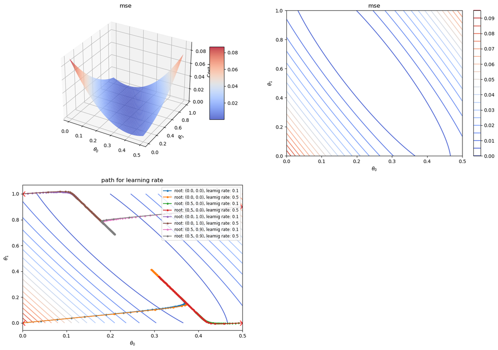

```python
import numpy as np
import matplotlib.pyplot as plt
from mpl_toolkits.mplot3d import Axes3D
from matplotlib import cm

# 数据集
X_raw = np.array([0.1, 0.2, 0.3, 0.4, 0.5])
y = np.array([0.3, 0.35, 0.41, 0.48, 0.54])

# 添加偏置项
X = np.column_stack((np.ones_like(X_raw), X_raw))

# 计算损失函数
def compute_cost(X, y, theta):
    m = len(y)
    predictions = X.dot(theta)
    cost = np.sum((predictions - y) ** 2) / (2 * m)
    return cost

# 梯度下降
def gradient_descent(X, y, theta, alpha, iterations):
    m = len(y)
    cost_history = []
    theta_history = [theta.copy()]

    for i in range(iterations):
        predictions = X.dot(theta)
        errors = predictions - y

        # 计算梯度
        gradients = X.T.dot(errors) / m

        # 更新参数
        theta = theta - alpha * gradients

        # 记录参数和损失
        cost_history.append(compute_cost(X, y, theta))
        theta_history.append(theta.copy())

    return theta, cost_history, np.array(theta_history)

# 1. 绘制均方误差函数的3D曲面
theta0_vals = np.linspace(0, 0.5, 100)
theta1_vals = np.linspace(0, 1.0, 100)
J_vals = np.zeros((len(theta0_vals), len(theta1_vals)))

for i, t0 in enumerate(theta0_vals):
    for j, t1 in enumerate(theta1_vals):
        theta = np.array([t0, t1])
        J_vals[i, j] = compute_cost(X, y, theta)

# 创建网格
T0, T1 = np.meshgrid(theta0_vals, theta1_vals)

# 绘制3D曲面
fig = plt.figure(figsize=(18, 12))

# 3D曲面图
ax1 = fig.add_subplot(221, projection='3d')
surf = ax1.plot_surface(T0, T1, J_vals.T, cmap=cm.coolwarm, alpha=0.8)
ax1.set_xlabel(r'$\theta_0$')
ax1.set_ylabel(r'$\theta_1$')
ax1.set_zlabel('Cost J')
ax1.set_title('mse')
fig.colorbar(surf, ax=ax1, shrink=0.5, aspect=5)

# 等高线图
ax2 = fig.add_subplot(222)
contour = ax2.contour(T0, T1, J_vals.T, 20, cmap=cm.coolwarm)
ax2.set_xlabel(r'$\theta_0$')
ax2.set_ylabel(r'$\theta_1$')
ax2.set_title('mse')
fig.colorbar(contour, ax=ax2)

# 2. 不同初始化位置和学习率的学习轨迹
# 初始化参数和学习率
initial_thetas = [
    np.array([0.0, 0.0]),  # 原点
    np.array([0.5, 0.0]),  # 右下角
    np.array([0.0, 1.0]),  # 左上角
    np.array([0.5, 0.9])   # 右上角
]

learning_rates = [0.1, 0.5]
iterations = 100

# 在等高线图上绘制不同的学习轨迹
ax3 = fig.add_subplot(223)
contour = ax3.contour(T0, T1, J_vals.T, 20, cmap=cm.coolwarm)

for theta_init in initial_thetas:
    for alpha in learning_rates:
        _, _, theta_history = gradient_descent(X, y, theta_init, alpha, iterations)
        ax3.plot(theta_history[:, 0], theta_history[:, 1], 'o-', markersize=3,
                 label=f'root: ({theta_init[0]}, {theta_init[1]}), learnig rate: {alpha}')
        # 标记起始点
        ax3.plot(theta_init[0], theta_init[1], 'rx', markersize=10)

ax3.set_xlabel(r'$\theta_0$')
ax3.set_ylabel(r'$\theta_1$')
ax3.set_title('path for learning rate')
ax3.legend(loc='upper right', fontsize='small')
```

```
最优参数：θ₀ = 0.2330, θ₁ = 0.6100
```

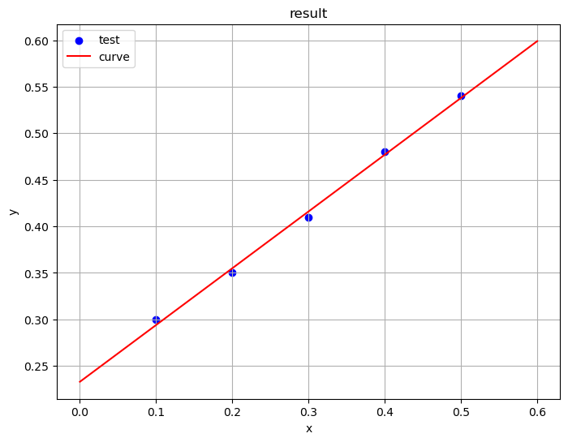

```python
# 3. 增大学习率，观察发散现象
ax4 = fig.add_subplot(224)
contour = ax4.contour(T0, T1, J_vals.T, 20, cmap=cm.coolwarm)

# 使用不同的学习率
high_learning_rates = [0.5, 1.0, 1.5, 2.0]
theta_init = np.array([0.3, 0.3])  # 固定初始点

for alpha in high_learning_rates:
    _, _, theta_history = gradient_descent(X, y, theta_init, alpha, 30)  # 减少迭代次数以便观察
    ax4.plot(theta_history[:, 0], theta_history[:, 1], 'o-', markersize=3,
             label=f'学习率: {alpha}')
    # 标记起始点
    ax4.plot(theta_init[0], theta_init[1], 'rx', markersize=10)

ax4.set_xlabel(r'$\theta_0$')
ax4.set_ylabel(r'$\theta_1$')
ax4.set_title('不同学习率下的收敛/发散现象')
ax4.legend(loc='upper right')

# 调整布局
plt.tight_layout()
plt.show()

# 打印最优参数（使用解析解）
X_transpose = X.T
theta_optimal = np.linalg.inv(X_transpose.dot(X)).dot(X_transpose).dot(y)
print(f"最优参数：θ₀ = {theta_optimal[0]:.4f}, θ₁ = {theta_optimal[1]:.4f}")

# 绘制拟合线
plt.figure(figsize=(8, 6))
plt.scatter(X_raw, y, color='blue', label='test')
x_range = np.linspace(0, 0.6, 100)
plt.plot(x_range, theta_optimal[0] + theta_optimal[1] * x_range, 'r-', label='curve')
plt.xlabel('x')
plt.ylabel('y')
plt.title('result')
plt.legend()
plt.grid(True)
plt.show()
```

[output not shown]

调整SGD算法中$\text{batch\_size}$的大小，观察结果的变化。对较大规模的数据集，$\text{batch\_size}$过小和过大分别有什么缺点？

**batch_size过小的缺点**：

1. 梯度估计噪声大，训练不稳定
2. 无法充分利用向量化计算，计算效率低
3. 可能导致收敛到局部最优解
4. 内存利用效率低

**batch_size过大的缺点**：

1. 每次迭代计算量大，更新频率低
2. 容易陷入局部最优解
3. 内存需求大，可能超出GPU/内存容量
4. 泛化性能可能下降

4.3节SGD算法的代码中，我们采用了固定迭代次数的方式，但是这样无法保证程序执行完毕时迭代已经收敛，也有可能迭代已收敛而程序还在运行。另一种方案是，如果损失函数值连续$M$次迭代都没有减小，或者减小的量小于某个预设精度$\epsilon$（例如$10^{-6}$），就终止迭代。请实现该控制方案，并思考它和固定迭代次数之间的利弊。能不能将这两种方案同时使用呢？

结合固定迭代次数和早停策略的实现思路：

```
def sgd_with_early_stopping(X, y, theta_init, alpha, max_iter, epsilon=1e-6, patience=M):
    theta = theta_init.copy()
    m = len(y)
    loss_history = []
    no_improvement_count = 0
    best_loss = float('inf')

    for i in range(max_iter):
        # 计算当前损失
        predictions = X.dot(theta)
        loss = np.mean((predictions - y) ** 2) / 2
        loss_history.append(loss)

        # 早停检查
        if loss < best_loss - epsilon:
            best_loss = loss
            no_improvement_count = 0
        else:
            no_improvement_count += 1

        if no_improvement_count >= patience:
            print(f"Early stopping at iteration {i}")
            break

        # 计算梯度并更新参数
        gradient = X.T.dot(predictions - y) / m
        theta = theta - alpha * gradient

    return theta, loss_history
```

**两种方案的利弊**：

- 固定迭代次数：简单易实现，但可能导致过早停止或不必要的计算
- 早停策略：可以自适应地停止训练，但需要额外存储和计算

**同时使用两种方案的好处**：

1. 设置最大迭代次数作为安全上限
2. 使用早停策略在收敛时提前终止
3. 避免无限循环的风险
4. 在有限时间内获得最佳结果

这种组合方法既保证了算法不会无限运行，又能在模型收敛时及时停止，是一种实用的优化策略。

# 第五章作业

机器学习的基本假设是：A. 在训练和测试数据中存在相同的模式。B. 训练数据和测试数据数量相同。C. 测试数据是训练数据的一部分。D. 训练数据的量足够多，可以训练出好的模型。

A

机器学习的基本假设是训练数据和测试数据来自同一分布，即它们具有相同的统计特性和模式。这是机器学习能够工作的前提，因为模型在训练数据上学习到的模式才能应用于测试数据。选项B不正确，因为训练和测试数据数量通常不同；选项C不正确，因为测试数据应该是模型未见过的新数据；选项D虽然训练数据量足够很重要，但这不是机器学习的基本假设。

列说法正确的是：A. 为了防止过拟合，正则化系数越大越好。B. 为了防止过拟合，应当选择尽可能简单的模型。C. 交叉验证方法中虽然所有数据都被用到，但是不存在信息泄露。D. 正则化系数$\lambda$可以通过损失函数对$\lambda$的梯度为零计算出来。

C

交叉验证确实使用了所有数据（每个样本都会作为训练集和验证集），但每次验证时使用的都是训练过程中未见过的数据，因此不存在信息泄露。选项A不正确，正则化系数过大会导致欠拟合；选项B部分正确但过于绝对，模型复杂度应该适中而非一味追求简单；选项D不正确，正则化系数$\lambda$通常是通过交叉验证等方法选择的超参数，而非通过梯度计算得出。

假如数据中不存在噪声，过拟合现象是否会消失？

会发生，即使数据中不存在噪声，过拟合现象仍可能发生。过拟合不仅与数据噪声有关，还与模型复杂度、训练样本数量的关系有关。当模型过于复杂而训练样本有限时，即使数据完全无噪声，模型仍可能"记住"训练数据的特定模式而非学习到真正的数据生成规律，导致泛化能力差。

机器学习可模型是否可以预测毫无规律的真随机数？试从统计规律的角度解释原因。

从统计规律角度看，真正的随机数在定义上是不可预测的，不存在可被学习的模式或规律。机器学习模型只能学习和预测数据中存在的模式和规律。如果数据是完全随机的，模型将无法找到任何有意义的模式进行学习，其预测结果将不会比随机猜测更好。

除了学习率，第 4 章的线性回归模型中还有哪些超参数？数据集大小$N$是超参数吗？

线性回归模型的主要超参数包括：

1. 学习率（梯度下降中）
2. 正则化系数$\lambda$（如果使用L1或L2正则化）
3. 迭代次数或收敛阈值（梯度下降中）
4. 批量大小（如果使用小批量梯度下降）

N不是超参数

在实践中，如果模型在测试集上的效果不好，如何判断模型是欠拟合还是过拟合？

- 如果模型在训练集和测试集上都表现不佳，通常是欠拟合，表明模型能力不足，无法捕捉数据中的模式。
- 如果模型在训练集上表现很好但在测试集上表现差，通常是过拟合，表明模型过度拟合了训练数据中的噪声。

# 第六章作业

以下关于最大似然估计的表述中正确的是：

A. 以概率为输出的模型常用最大似然估计得到损失函数。

B. 由于最大似然估计优化的是对数似然而非似然，得到的结果只是最优解的近似。

C. 最大似然估计与交叉熵的训练目标不等价。

D. 最大似然估计中引入了概率分布，所以不能采用梯度下降法来优化最大似然估计导出的损失函数。

- 选项A正确：概率模型（如逻辑回归、神经网络等）通常使用最大似然估计原理推导损失函数，如交叉熵损失。
- 选项B错误：最大似然估计直接优化似然函数的对数形式，这是为了计算方便，但得到的结果与直接优化似然函数是等价的，不是近似。
- 选项C错误：对于分类问题，最大似然估计与交叉熵是等价的。最小化交叉熵等价于最大化对数似然。
- 选项D错误：最大似然估计导出的损失函数（如交叉熵）完全可以使用梯度下降法优化，这是深度学习中的标准做法。

以下关于分类问题的说法中不正确的是：

A. 分类问题中，最后往往需要通过阈值来决定样本最后的标签。对于标签为 0 或 1 的二分类问题，当 $f_θ(x)$ 的数值大于 0.5 时即可认为标签为 1，反之亦然。

B. 如果使用确定性模型，将会导致模型对于参数无法微分，因此我们需要使用概率模型来建模问题。

C. 对于多分类问题，在设计损失函数时仍然可以采用交叉熵损失，如果有$K$类别，损失函数就是每一类的损失相加。

D. softmax 函数可以看作是逻辑斯蒂函数在多分类情况下的延伸，因此也可以用 softmax 函数作为二分类问题的损失函数。

- 选项A正确：在二分类问题中，通常使用0.5作为阈值来决定最终类别。
- 选项B正确：确定性模型会导致决策边界处不可微分，使用概率模型可以解决这个问题。
- 选项C正确：多分类问题常用交叉熵损失，对所有类别的损失求和。
- 选项D错误：softmax函数确实是逻辑斯蒂函数在多分类上的推广，但softmax函数本身不是损失函数，而是激活函数。多分类问题的损失函数是softmax与交叉熵的组合。对于二分类问题，通常使用sigmoid函数与二元交叉熵，而非softmax。

以下关于分类问题评价指标的说法，不正确的是：

A. 精确率是指分类正确的样本占全体样本的比例。

B. 准确率是指分类为正例的样本中标签为正例的比例。

C. 召回率是指标签为正例的样本中分类为正例的比例。

D. AUC 是由阈值从小到大增加过程中，模型分类的假阳性率以及真阳性率变化趋势进行绘制的。

- 选项A错误：这描述的是准确率(Accuracy)，而非精确率(Precision)。精确率是指被预测为正例的样本中真正的正例的比例。
- 选项B错误：这描述的是精确率(Precision)，而非准确率(Accuracy)。
- 选项C正确：召回率(Recall)是指所有真实正例中被正确预测为正例的比例。
- 选项D正确：AUC是ROC曲线下的面积，ROC曲线是通过改变阈值，绘制不同阈值下的假阳性率(FPR)和真阳性率(TPR)得到的。

逻辑斯蒂回归虽引入了非线性的逻辑斯蒂函数，但通常仍然被视为线性模型，试从模型参数化假设的角度解释原因。

逻辑斯蒂回归虽然使用了非线性的sigmoid函数，但仍被视为线性模型，原因在于：

从参数化的角度看，逻辑斯蒂回归中的决策边界是线性的。模型形式为： $$P(y=1|x) = \sigma(w^T x + b)$$

其中$\sigma$是sigmoid函数，$w^T x + b$是关于参数$w$和$b$的线性函数。虽然sigmoid函数本身是非线性的，但它只是将线性函数的输出映射到(0,1)区间，用于表示概率。决策边界由$w^T x + b = 0$确定，这是一个超平面，具有线性性质。

因此，逻辑斯蒂回归的参数是线性组合的形式，决策边界是线性的，所以被归类为线性模型。

如果某模型的 AUC 低于 0.5，是否有办法立即得到一个 AUC 高于 0.5 的模型？

如果一个模型的AUC低于0.5，说明该模型的预测能力比随机猜测还差，即模型倾向于将正例预测为负例，将负例预测为正例。

通过简单地将模型的预测概率$p$变为$1-p$，或者直接翻转预测的类别标签，就可以得到一个AUC高于0.5的模型。这相当于模型"反着预测"，将原来预测为高概率的样本现在预测为低概率，反之亦然。

数学上，如果原模型$f$的AUC为$a < 0.5$，则新模型$g(x) = 1 - f(x)$的AUC将为$1 - a > 0.5$。

对于一个二分类任务，数据的标签和对于预测正例的概率如下表所示，试画出 ROC 曲线并计算模型的 AUC 值。

表 6-4 习题 6 概率表

| $n_1$ | $n_2$ | $n_3$ | $n_4$ | $p_1$ | $p_2$ | $p_3$ | $p_4$ |
| --- | --- | --- | --- | --- | --- | --- | --- |
| 0.15 | 0.21 | 0.74 | 0.45 | 0.71 | 0.48 | 0.52 | 0.34 |

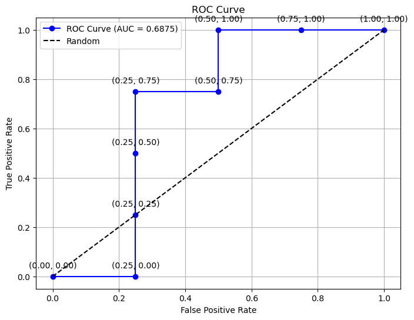

```
计算得到的AUC值为: 0.6875
```

```python
import numpy as np
import matplotlib.pyplot as plt
from sklearn.metrics import auc

# 数据
neg_probs = np.array([0.15, 0.21, 0.74, 0.45])  # 负样本的预测概率
pos_probs = np.array([0.71, 0.48, 0.52, 0.34])  # 正样本的预测概率

# 合并数据并排序
labels = np.array([0, 0, 0, 0, 1, 1, 1, 1])  # 0表示负样本，1表示正样本
probs = np.concatenate([neg_probs, pos_probs])
indices = np.argsort(probs)[::-1]  # 按概率降序排序

sorted_labels = labels[indices]
sorted_probs = probs[indices]

# 计算TPR和FPR
n_pos = np.sum(labels == 1)
n_neg = np.sum(labels == 0)
tpr = np.cumsum(sorted_labels == 1) / n_pos
fpr = np.cumsum(sorted_labels == 0) / n_neg

# 添加起始点(0,0)
tpr = np.insert(tpr, 0, 0)
fpr = np.insert(fpr, 0, 0)

# 计算AUC
roc_auc = auc(fpr, tpr)

# 绘制ROC曲线
plt.figure(figsize=(8, 6))
plt.plot(fpr, tpr, marker='o', linestyle='-', color='b', label=f'ROC Curve (AUC = {roc_auc:.4f})')
plt.plot([0, 1], [0, 1], 'k--', label='Random')
plt.xlabel('False Positive Rate')
plt.ylabel('True Positive Rate')
plt.title('ROC Curve')
plt.legend()
plt.grid(True)

# 显示数据点的值
for i in range(len(fpr)):
    plt.annotate(f'({fpr[i]:.2f}, {tpr[i]:.2f})', (fpr[i], tpr[i]),
                 textcoords="offset points", xytext=(0,10), ha='center')

plt.show()

print(f"计算得到的AUC值为: {roc_auc:.4f}")
```

设数据集中包含样本$x_1,\ldots,x_N$，其中有$M$个正样本，$N-M$个负样本。模型$\hat{f}$预测任意两个不同样本$x_i,x_j$属于正类的概率$\hat{f}(x_i)$与$\hat{f}(x_j)$不同。证明从中均匀随机选取一个正样本$p$和一个负样本$n$，有

$$P(\hat{f}(n) < \hat{f}(p)) = \text{AUC}(\hat{f})$$

(提示：考虑 ROC 曲线上每一段横线和竖线的意义，对于选出的负样本$n$，预测值更大的正样本数量和TPR有什么关系？FPR呢？)

对于随机选取的一对样本(p,n)，其中p是正样本，n是负样本：

- 当$\hat{f}(n) < \hat{f}(p)$时，表示模型正确地给予正样本比负样本更高的预测概率
- 这个概率可以表示为所有可能的正负样本对中，有多大比例满足$\hat{f}(n) < \hat{f}(p)$

考虑ROC曲线的构造方法：

- 按预测概率从高到低排序所有样本
- 从(0,0)开始，每遇到一个正样本，向上移动1/M；每遇到一个负样本，向右移动1/(N-M)

对于每个负样本n，记其预测值为$\hat{f}(n)$，则所有预测值大于$\hat{f}(n)$的正样本数量为M×TPR(n)，其中TPR(n)是将$\hat{f}(n)$作为阈值时的真阳性率。

因此，对于随机选取的一对(p,n)，满足$\hat{f}(n) < \hat{f}(p)$的概率为：

$$P(\hat{f}(n) < \hat{f}(p)) = \frac{1}{M(N-M)}\sum_{i=1}^{N-M}\sum_{j=1}^{M} I[\hat{f}(n_i) < \hat{f}(p_j)]$$

其中$I$是指示函数，当条件满足时为1，否则为0。

这个双重求和可以重写为：

$$P(\hat{f}(n) < \hat{f}(p)) = \frac{1}{N-M}\sum_{i=1}^{N-M} \frac{\text{预测值大于}\hat{f}(n_i)\text{的正样本数量}}{M}$$$$= \frac{1}{N-M}\sum_{i=1}^{N-M} \text{TPR}(n_i)$$

而AUC正是ROC曲线下的面积，可以表示为：

$$\text{AUC} = \int_{0}^{1} \text{TPR}(FPR) d(FPR)$$

在离散情况下，这等价于：

$$\text{AUC} = \sum_{i=1}^{N-M} \text{TPR}(n_i) \cdot \frac{1}{N-M}$$

因此，$P(\hat{f}(n) < \hat{f}(p)) = \text{AUC}(\hat{f})$，证毕。

对于K分类 softmax 函数，试推导其中一个分类的逻辑斯谛值总可以设为 0，进而K分类逻辑斯谛回归模型其实只需要使用K − 1个参数向量即可完成等价建模，而具体的二分类逻辑斯谛回归的形式则正是 softmax 函数在K = 2时由这样化简得到的。

在K分类问题中，softmax函数将实数向量$z = (z_1, z_2, ..., z_K)$映射为概率分布：

$$\sigma(z)_i = \frac{e^{z_i}}{\sum_{j=1}^{K} e^{z_j}}$$

我们可以证明，其中一个分类的逻辑斯谛值可以设为0，而不改变最终的概率分布。

假设我们将所有$z_i$都减去$z_K$，得到新的向量$z' = (z_1-z_K, z_2-z_K, ..., z_{K-1}-z_K, 0)$。

对于任意$i \in \{1,2,...,K\}$，计算新的softmax值：

$$\sigma(z')_i = \frac{e^{z_i-z_K}}{\sum_{j=1}^{K} e^{z_j-z_K}} = \frac{e^{z_i}/e^{z_K}}{\sum_{j=1}^{K} e^{z_j}/e^{z_K}} = \frac{e^{z_i}}{\sum_{j=1}^{K} e^{z_j}} = \sigma(z)_i$$

这表明，将最后一个分量设为0（即$z_K = 0$），其他分量相应调整为$z_i - z_K$，得到的概率分布与原来完全相同。

因此，K分类问题只需要K-1个参数向量，因为第K个类别的参数可以固定为0。

当K=2时，softmax函数变为：

$$\sigma(z)_1 = \frac{e^{z_1}}{e^{z_1} + e^{z_2}}$$$$\sigma(z)_2 = \frac{e^{z_2}}{e^{z_1} + e^{z_2}}$$

如果我们设$z_2 = 0$，则：

$$\sigma(z)_1 = \frac{e^{z_1}}{e^{z_1} + 1}$$$$\sigma(z)_2 = \frac{1}{e^{z_1} + 1}$$

令$z_1 = \theta^T x$，则：

$$\sigma(z)_1 = \frac{e^{\theta^T x}}{e^{\theta^T x} + 1} = \frac{1}{1 + e^{-\theta^T x}}$$$$\sigma(z)_2 = \frac{1}{e^{\theta^T x} + 1} = 1 - \sigma(z)_1$$

$\square$

从二分类到多分类。

(1) 推导 softmax 函数$\sigma(z)$对z的梯度。

(2) 将$\sigma(z)$作为模型预测的概率分布，分别用 MLE 和交叉熵计算K分类问题的损失函数，两者的结果是否相同?

(1)我们需要计算$\frac{\partial \sigma(z)_i}{\partial z_j}$，即softmax函数第i个输出对第j个输入的偏导数。

分两种情况：

**情况1：i = j**

$$\frac{\partial \sigma(z)_i}{\partial z_i} = \frac{\partial}{\partial z_i}\left(\frac{e^{z_i}}{\sum_{k=1}^{K} e^{z_k}}\right)$$

使用商的求导法则：

$$\frac{\partial \sigma(z)_i}{\partial z_i} = \frac{e^{z_i} \cdot \sum_{k=1}^{K} e^{z_k} - e^{z_i} \cdot e^{z_i}}{(\sum_{k=1}^{K} e^{z_k})^2}$$$$= \frac{e^{z_i}}{\sum_{k=1}^{K} e^{z_k}} \cdot \left(1 - \frac{e^{z_i}}{\sum_{k=1}^{K} e^{z_k}}\right)$$$$= \sigma(z)_i \cdot (1 - \sigma(z)_i)$$

**情况2：i ≠ j**

$$\frac{\partial \sigma(z)_i}{\partial z_j} = \frac{\partial}{\partial z_j}\left(\frac{e^{z_i}}{\sum_{k=1}^{K} e^{z_k}}\right)$$$$= \frac{0 \cdot \sum_{k=1}^{K} e^{z_k} - e^{z_i} \cdot e^{z_j}}{(\sum_{k=1}^{K} e^{z_k})^2}$$$$= -\frac{e^{z_i}}{\sum_{k=1}^{K} e^{z_k}} \cdot \frac{e^{z_j}}{\sum_{k=1}^{K} e^{z_k}}$$$$= -\sigma(z)_i \cdot \sigma(z)_j$$

综合两种情况，梯度可以写为：

$$\frac{\partial \sigma(z)_i}{\partial z_j} = \sigma(z)_i \cdot (\delta_{ij} - \sigma(z)_j)$$

其中$\delta_{ij}$是克罗内克函数，当i=j时为1，否则为0。

用矩阵形式表示，如果令$S = diag(\sigma(z)) - \sigma(z)\sigma(z)^T$，则softmax函数的雅可比矩阵为S。

(2)MLE与交叉熵损失函数的比较

**最大似然估计(MLE)推导：**

假设真实标签为one-hot编码的向量$y$，其中$y_i = 1$表示样本属于第i类，其他位置为0。

模型预测的概率分布为$\sigma(z)$，则样本的似然函数为：

$$L(\theta) = \prod_{i=1}^{K} \sigma(z)_i^{y_i}$$

对数似然为：

$$\log L(\theta) = \sum_{i=1}^{K} y_i \log \sigma(z)_i$$

由于MLE是最大化似然函数，而在优化中通常最小化损失函数，所以MLE对应的损失函数为负对数似然：

$$L_{MLE} = -\log L(\theta) = -\sum_{i=1}^{K} y_i \log \sigma(z)_i$$

**交叉熵损失函数：**

交叉熵定义为：

$$H(y, \sigma(z)) = -\sum_{i=1}^{K} y_i \log \sigma(z)_i$$

可以看出，MLE得到的损失函数与交叉熵损失函数完全相同。这表明，在多分类问题中，使用softmax函数作为预测的概率分布时，最大化似然等价于最小化交叉熵。

因此，两者的结果是相同的。

关于随机变量X存在两个概率分布p(x)和q(x)，证明其 KL 散度总为非负，即$D_{KL}(p||q) \geq 0$，并且当且仅当p(x) = q(x)时，$D_{KL}(p||q) = 0$。

我们可以利用Jensen不等式来证明。Jensen不等式指出，对于凸函数$f$和随机变量$X$，有：

$$f(E[X]) \leq E[f(X)]$$

其中$E[X]$表示$X$的期望。当且仅当$X$为常数时，等号成立。

考虑函数$f(x) = -\log(x)$，这是一个凸函数。我们可以将KL散度重写为：

$$D_{KL}(p||q) = \sum_{x} p(x) \log \frac{p(x)}{q(x)} = -\sum_{x} p(x) \log \frac{q(x)}{p(x)}$$

定义随机变量$Z = \frac{q(X)}{p(X)}$，其中$X$遵循分布$p(x)$。则：

$$E[Z] = \sum_{x} p(x) \cdot \frac{q(x)}{p(x)} = \sum_{x} q(x) = 1$$

应用Jensen不等式：

$$f(E[Z]) \leq E[f(Z)]$$$$-\log(E[Z]) \leq E[-\log(Z)]$$$$-\log(1) \leq -\sum_{x} p(x) \log \frac{q(x)}{p(x)}$$$$0 \leq D_{KL}(p||q)$$

因此，$D_{KL}(p||q) \geq 0$，证明了KL散度的非负性。

根据Jensen不等式，当且仅当$Z = \frac{q(X)}{p(X)}$为常数时，等号成立。也就是说，对于所有$x$使得$p(x) > 0$，必须有：

$$\frac{q(x)}{p(x)} = c$$

其中$c$是常数。由于$p$和$q$都是概率分布，满足：

$$\sum_{x} p(x) = \sum_{x} q(x) = 1$$

代入上面的等式：

$$\sum_{x} p(x) = \sum_{x} c \cdot p(x) = c \sum_{x} p(x) = c \cdot 1 = c$$

因此$c = 1$，这意味着对于所有$x$，$q(x) = p(x)$。

所以，$D_{KL}(p||q) = 0$当且仅当$p(x) = q(x)$对于所有$x$成立。

# 第八章作业

1960 年代，马文·明斯基 (Marvin Minsky) 和西摩·佩珀特 (Seymour Papert) 利用____证明了感知机的局限性，导致神经网络的研究陷入寒冬。

A. 被废消失问题

B. 异或问题

C. 线性分类问题

B

下列关于神经网络的说法正确的是：

A. 神经网络的设计仿照生物的神经元，已经可以完成和生物神经一样的功能。

B. 神经元只能通过前馈方式连接，否则无法进行反向传播。

C. 多层感知机相比于单层感知机有很大提升，其核心在于非线性激活函数。

D. 多层感知机没有考虑不同特征之间的关联，因此建模能力不如双线性模型。

- 选项A错误：虽然神经网络设计受到生物神经元的启发，但现代神经网络与生物神经元的工作方式有很大差异，远未达到完成生物神经元全部功能的程度。
- 选项B错误：神经网络可以有多种连接方式，包括前馈、循环、跳跃连接等，并非只能通过前馈方式连接。循环神经网络(RNN)就是一个反例。
- 选项C正确：多层感知机之所以比单层感知机强大，关键在于引入了非线性激活函数。如果没有非线性激活函数，多层网络的叠加仍然只能表示线性变换，无法解决XOR等非线性问题。
- 选项D错误：多层感知机通过多层结构和非线性激活函数可以学习特征之间的复杂关联，其建模能力通常强于双线性模型。

为什么（结构固定的）神经网络是参数化模型？它对输入的参数化假设是什么？

神经网络是参数化模型，因为：

1. **固定结构，可变参数**：神经网络的结构（层数、每层神经元数量、连接方式等）是预先设定的，而权重和偏置是可学习的参数。这些参数通过训练过程优化，使网络能够拟合训练数据。
2. **函数逼近器**：从理论上讲，神经网络是通用函数逼近器，可以通过调整参数来近似任意连续函数。

神经网络对输入的参数化假设主要包括：

1. **局部性假设**：相邻层之间的神经元连接权重捕捉了输入特征之间的局部关系。
2. **层次性假设**：深层网络中，较低层学习低级特征，较高层学习更抽象的高级特征，形成层次化的特征表示。
3. **平滑性假设**：对于相似的输入，神经网络应该产生相似的输出，这反映在激活函数的连续性和可微性上。
4. **稀疏性假设**：在许多应用中，假设高维输入数据可以用较低维度的表示来有效描述。

这些假设使得神经网络能够在有限的训练数据上学习到泛化能力较强的模型。

试计算逻辑斯蒂函数、tanh 函数的取值区间，并根据反向传播的公式思考：当 MLP 的层数比较大时，其梯度计算会有什么影响？

当$x \to -\infty$时，$\sigma(x) \to 0$ 当$x \to +\infty$时，$\sigma(x) \to 1$ 因此，逻辑斯蒂函数的取值区间是$(0, 1)$

当$x \to -\infty$时，$\tanh(x) \to -1$ 当$x \to +\infty$时，$\tanh(x) \to 1$ 因此，tanh函数的取值区间是$(-1, 1)$

在反向传播中，梯度通过链式法则从输出层向输入层传递。对于一个L层的MLP，第l层的梯度计算涉及到从第L层到第l层的所有梯度相乘。

主要影响包括：

1. **梯度消失问题**： 当使用sigmoid或tanh激活函数时，这些函数的导数在输入绝对值较大时接近于0。当网络层数很多时，这些小梯度相乘会导致前面层的梯度接近于0，使得这些层难以学习。
2. **梯度爆炸问题**： 相反，如果权重初始化不当或学习率过大，梯度可能会变得非常大，导致参数更新过度，模型无法收敛。
3. **长期依赖问题**： 在深层网络中，前面层的梯度依赖于所有后续层的计算，这使得捕捉长期依赖关系变得困难。

8.3 节中提到，将值域为(-1, 1)的tanh(x)变形可以使值域拓展到(a, b)。对于更一般的情况，推导将[m, n]区间均匀映射到[a, b]区间的变换f。均匀映射可以理解为，对于任意[u, v] ⊂ [m, n]，都有 $\frac{v-u}{n-m} = \frac{f(v)-f(u)}{b-a}$。

要将区间[m, n]均匀映射到区间[a, b]，我们需要找到一个线性函数f，使得：

- f(m) = a
- f(n) = b
- 对于任意[u, v] ⊂ [m, n]，满足$\frac{v-u}{n-m} = \frac{f(v)-f(u)}{b-a}$

线性函数的一般形式为：f(x) = kx + c，其中k和c是待定系数。

根据条件：

1. f(m) = km + c = a
2. f(n) = kn + c = b

解这个方程组： 从式2减去式1：k(n - m) = b - a 得到：k = $\frac{b-a}{n-m}$

将k代入式1：$\frac{b-a}{n-m}m + c = a$ 解得：c = $a - \frac{b-a}{n-m}m = \frac{an-bm}{n-m}$

因此，映射函数为： $f(x) = \frac{b-a}{n-m}x + \frac{an-bm}{n-m}$

# 第九章作业

以下关于CNN的说法正确的是：

A. 卷积运算考虑了三维的空间信息，所以CNN只能用来完成图像相关的任务。

B. 池化操作进行了降采样，将会丢弃部分信息，影响模型效果。

C. 由卷积层得到的特征也需要经过非线性激活函数，来提升模型的表达能力。

D. 填充操作虽然保持了输出的尺寸，但是引入了与输入无关的信息，干扰特征提取。

- 选项A错误：虽然卷积运算可以处理空间信息，但CNN不仅能处理图像任务，还能用于语音、文本等一维、二维、三维数据。
- 选项B错误：池化操作确实会丢弃部分信息，但其目的是降采样、增强特征的平移不变性和减少计算量，未必总是负面影响。
- 选项C正确：卷积层输出的特征需要经过非线性激活函数（如ReLU），否则多层卷积的叠加仍然是线性变换，无法拟合复杂函数。
- 选项D错误：填充操作的主要目的是保持输出尺寸，虽然引入了边界信息，但不会显著干扰特征提取。

以下关于CNN中卷积层和池化层的描述正确的是：

A. 卷积层和池化层必须交替出现。

B. 池化层只有最大池化和平均池化两种。

C. 池化层的主要目的是为了减少计算复杂度。

D. 卷积层中有许多不同的卷积核，每个卷积核在输入的一部分区域上做运算，合起来覆盖完整的输入。

- 选项A错误：卷积层和池化层可以任意组合，不一定要交替出现。
- 选项B错误：池化层除了最大池化和平均池化，还有其他类型（如L2池化、全局池化等）。
- 选项C正确，但不是池化层唯一或主要的目的，池化还可以增强特征的平移不变性。
- 选项D正确：卷积层通常包含多个卷积核，每个卷积核在输入的不同局部区域滑动，提取不同的特征，最终覆盖整个输入。

CNN的卷积层中还有一个常用参数是步长（stride），表示计算卷积时，卷积核每次移动的距离。假图9-5的示例中，卷积核每次移动一格，步长为1，它的左上角经过(0,0)至(2,2)共9个点。如果将步长改为2，卷积核每次移动两格，左上角只经过(0,0)、(0,2)、(2,0)、(2,2)共4个点，以此类推。假设输入宽为$W$，在宽度方向填充长度为$W_p$，卷积核宽为$W_k$，在宽度方向的步长为$S_w$。假设所有除法都可以整除，推导卷积层输出矩阵的宽度$W_{out}$。

设输入宽度为$W$，填充为$W_p$，卷积核宽度为$W_k$，步长为$S_w$，则输出宽度$W_{out}$为：

$$ W_{out} = \frac{W + 2W_p - W_k}{S_w} + 1 $$

# 第十章作业

以下关于RNN的说法不正确的是：

A. RNN的权值更新通过与MLP相同的传统反向传播算法进行计算。

B. RNN的中间结果不仅取决于当前的输入，还取决于上一时刻的中间结果。

C. RNN结构灵活，可以控制输入输出的数目，以针对不同的任务。

D. RNN中容易出现梯度消失或梯度爆炸问题，因此很难应用在序列较长的任务上。

RNN的权值更新虽然本质上也是通过反向传播实现的，但RNN采用的是“反向传播通过时间（BPTT, Backpropagation Through Time）”算法，而不是MLP的标准反向传播。B、C、D三项均为RNN的正确描述。

以下关于GRU的说法正确的是：

A. GRU主要改进了RNN从中间结果到输出之间的结构，可以提升RNN的表达能力。

B. GRU相较于一般的RNN更为复杂，但训练反而更加简单。

C. 没有一种网络结构可以完整保留过去的所有信息，GRU只是合适的取舍方式。

D. 重置门和更新门的输入完全相同，因此可以合并为一个门。

- A项正确，GRU通过门控机制改进了RNN的结构，提升了表达能力。
- B项错误，GRU结构比普通RNN复杂，但训练并不一定更简单。
- C项正确，没有一种网络结构可以完整保留所有历史信息，GRU只是做了合理的取舍。
- D项错误，重置门和更新门的功能和输入不同，不能合并为一个门。

在10.3动手实现GRU一节中，根据任务特点，我们用到的RNN的输入输出对应关系是什么？

在10.3节动手实现GRU时，RNN的输入通常是一个序列（如词向量序列），输出可以是：

- 每个时间步的输出（如序列标注任务）
- 只取最后一个时间步的输出（如序列分类任务）

GRU的重置门和更新门，哪个可以维护长期记忆？哪个可以捕捉短期信息？

- **更新门（update gate）**：可以维护长期记忆，决定保留多少过去的信息到当前状态。
- **重置门（reset gate）**：可以捕捉短期信息，决定当前输入和过去记忆的结合程度。

因此，更新门负责长期记忆，重置门负责短期记忆。

# 第十一章作业

以下关于SVM的说法不正确的是：

A. SVM的目标是寻找一个使最小几何间隔达到最大值的分割超平面

B. 分割超平面不会随(w,b)的幅值改变而改变，但是函数间隔却会随之改变

C. 为训练完成的SVM中添加新的不重要的样本点，模型给出的分隔平面可能不会改变

D. 样本函数间隔的数值越大，分类结果的确信度越大

C SVM训练完成后，决策边界完全由支持向量决定，添加非支持向量的样本点不会改变分隔平面。

以下关于核函数的说法不正确的是：

A. 核函数的数值大小反映了两个变量之间的相似度高低

B. SVM只着眼于内积计算，因此训练时可以使用核函数来代替特征映射$\varphi$

C. SVM在训练过程中不需要进行显式的特征映射，不过在预测时需要计算本进行特征映射

D. 核函数将特征映射和内积并为了一步进行计算，所以大大降低了时间复杂度

C SVM在训练和预测过程中都不需要进行显式的特征映射，而是通过核函数直接计算高维空间中的内积。

在逻辑斯蒂回归中，我们也用解析方式求出了模型参数，但是其中涉及复杂度很高的矩阵法法和矩阵求逆。为什么支持向量机的解析结果中不包含这类复杂运算？（提示：逻辑斯蒂回归和支持向量机分别考虑了样本到分隔平面的什么问题？）

逻辑斯蒂回归考虑所有样本点到分隔平面的距离，而SVM只关注支持向量（最接近决策边界的点）。SVM通过拉格朗日对偶问题转化，最终只需要计算支持向量相关的内积，大大简化了计算。

对于同一个数据集，逻辑斯蒂回归和支持向量机给出的分隔平面一样吗？用本章的Linear.csv数据集验证你的想法。试着给数据集中手动添加一些新的样本点，或者更改已有样本点的分类，两种算法给出的分隔平面有什么变化？

逻辑斯蒂回归和SVM通常给出不同的分隔平面：

- 逻辑斯蒂回归最大化所有样本的似然函数
- SVM最大化间隔（支持向量到分隔平面的距离）

添加新样本点时：

- 如果添加的样本点成为支持向量，SVM的分隔平面会改变
- 逻辑斯蒂回归会考虑所有样本点，所以分隔平面几乎总会改变

思考RBF核函数对应的φ(·)函数是什么。建议查阅相关文献来寻找答案。进一步思考输出为无穷维的特征映射φ(·)的意义是什么。

RBF核函数对应的特征映射φ(·)是无穷维的。RBF核函数可表示为：K(x,y) = exp(-γ||x-y||²)，对应于希尔伯特空间中的无穷维映射。这种映射的意义在于允许SVM在非常高维的空间中寻找线性分隔平面，从而在原始空间中形成非线性决策边界，提高分类能力。

试基于本章代码，标记出双螺旋数据上使用RBF核函数的SVM模型的支持向量，并讨论这些数据点成为支持向量的原因。

双螺旋数据是典型的非线性可分数据，支持向量通常位于两个螺旋的边界处。这些点成为支持向量的原因是它们最接近决策边界，对确定最优分隔超平面起关键作用。

试通过参数量与数据集大小的关系、参数更新方式等视角，分析和体会SVM模型的原问题对应参数化模型，而对偶问题对应非参数化模型。

- 原问题：参数化模型，参数量固定(w,b)，与数据量无关
- 对偶问题：非参数化模型，拉格朗日乘子数量等于训练样本数量

  当数据量增大时，对偶问题的参数量也增大，但由于稀疏性，实际起作用的只有支持向量对应的参数，使模型具有良好的泛化能力。